# Notebook

## 7. Sensitivity Check

Does the main finding (clinical environment is the strongest predictor) hold when restricted to users with longer, more detailed posts (body_text > 200 characters)?

**Sensitivity check -- detailed posts only (body_text > 200 chars):**  
**Staff quality (positive vs negative):** OR=1.42, p=0.2157 (holds)  
Positive staff: 60.4% positive (n=101) | Negative staff: 51.8% positive (n=110)  
**Method (medical vs surgical):** OR=1.08, p=0.8738 (holds)  
Medical: 53.4% positive (n=58) | Surgical: 51.6% positive (n=122)  
**Conclusion:** Main findings are robust to the detailed-posts restriction.

## 8. Counterintuitive Findings Worth Investigating

**1. Users who describe positive staff interactions mention fear/anxiety at higher rates (73.3% vs 32.6%).**  
Fisher's exact p=0.0000, OR=5.70. This correlation could reflect verbosity bias (users who write detailed accounts mention both staff quality and emotions more) or selection (anxious patients are more attuned to staff quality). We report the correlation without assuming causation.  
**2. Geographic variation: Asia reports 53% positive vs Canada at 35%.**  
(n=30 and n=31 respectively). This likely reflects differences in healthcare access, legal climate, and social stigma rather than method or support differences.

## 9. Geographic Context

The r/abortion community includes users from multiple regions (identified via post flair). Do experience patterns vary geographically?

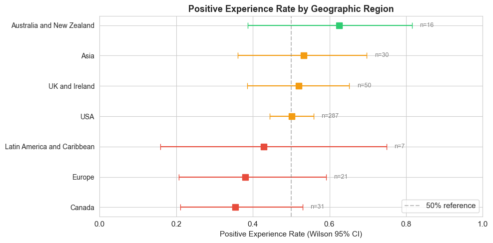

**Note:** Small sample sizes in several regions produce wide confidence intervals. Only regions with n >= 5 classified users are shown. Overlapping CIs for most regions mean we cannot reliably distinguish between them.

## 10. What Patients Are Saying

Quantitative patterns tell us what correlates with positive or negative experiences. The posts themselves capture nuance that keyword counts miss. Below are representative quotes illustrating the key findings.

Positive staff interaction predicting positive experience

> "Hi All, I am coming to the internet for support."  
> — r/abortion user, 2026-03-18

> "I began to freak out, not thinking it would happen so soon…I worried about all the changes that would come, to my body, our lives, etc."  
> — r/abortion user, 2026-04-01

Negative staff interaction predicting negative experience

> "I was 5 weeks and 6 days when I went in for my appointment."  
> — r/abortion user, 2026-04-03

> "I have a feeling I was treated very poorly in such a vulnerable time in my life."  
> — r/abortion user, 2026-03-21

Method did not determine experience (positive medical)

> "I went through a medical abortion yesterday, and after spending the previous weeks reading experiences to prepare, I thought I would contribute for anybody else out there going through the same thing."  
> — r/abortion user, 2026-03-17

> "i’m 28, never been pregnant before and don’t want kids ever."  
> — r/abortion user, 2026-03-21

Complicating the narrative: supported but still struggling

> "I found out I was pregnant last week due to my missed period, I automatically felt like I didn’t want to continue with the pregnancy."  
> — r/abortion user, 2026-04-02

> "I feel really guilty about it, but I know it was the right choice."  
> — r/abortion user, 2026-04-05